# Packages problem

Andrea Berardi

22 October 2019

## Problem

I have a number of objects to package and want to minimize the cost of paying for weight I do not need using the minimum number possible of package sizes. Assumption: pack sizes are integer.

The minimum cost of air will be the nearest integer to the item size. Judgement on the optimal number of pack sizes is arbitrary, as it presumes knoweldge of the average willingness to pay for air per pack, compared to the implementation costs for the number of pack sizes.

Here we assume that the cost per pack has a linear relationship with the pack size - this is completely arbitrary and should be adapted as needed.

The algorithm first initializes with pack sizes all equal to the ceiling integer for each item. Pack sizes are discarded one by one, discarding the one that minimizes the cost of air among the possible choices. It should be noted that under this assumption the largest package will always be the ceiling integer to the largest pack size. This should ideally be set manually instead to a reasonable size which would not prevent unexpectedly large items to be packed.

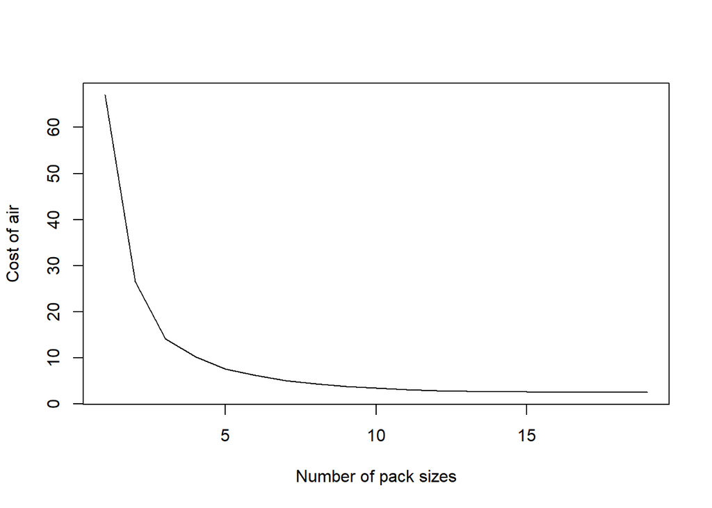

```r
# data simulation
set.seed(1234)
hist_data = rgamma(1000, 7.5, 1)
new_data = rgamma(100, 7.5, 1)

# assuming a simple linear regression of cost over size
cost_per_size = function(size) {
  10 + size * 5
}

train_data = sort(hist_data)
init_packs = unique(ceiling(train_data))

# initial data points
tree = list()
tree[[1]] = list(train_data, init_packs)

# allocate packages functions
select_pack = function(item, sizes) {
  ret =
    sapply(
      sizes,
      function(x, item) {
        ifelse(x - item < 0, NA, x - item)
      },
      item)
  if (all(is.na(ret)))
    return(NA)
  which.min(ret)
}

cost_extra = function(items, alloc, costs = pack_data$cost, cost_fun = cost_per_size) {
  theoretical_cost_item = cost_fun(items)
  pack_cost = costs[alloc]
  NA_costs = is.na(pack_cost)
  pack_cost[NA_costs] = 10000000
  air_cost = pack_cost - theoretical_cost_item
  return(sum(air_cost))
}

alloc_pack = function(content, sizes) {
  sapply(content, select_pack, sizes)
}

alloc_var_pack = function(pack_sizes, cost_per_size, items, round = FALSE) {
  n_packs = length(pack_sizes)
  if (round) {pack_sizes = ceiling(pack_sizes)}
  pack_costs = cost_per_size(pack_sizes)
  alloc = alloc_pack(items, pack_sizes)
  cost_extra(items, alloc, pack_costs, cost_per_size)
}

find_next_cluster = function(packs, boxes) {
  costs = sapply(1:length(boxes), function(x) {
    # print(boxes[-x])
    alloc_var_pack(boxes[-x], cost_per_size, train_data)})
  # print(costs)
  return(costs)
}

step_packs = list(init_packs)
x = list(find_next_cluster(train_data, step_packs[[1]]))
step_packs[[2]] = step_packs[[1]][-which.min(x[[1]])]
for (i in 2:(length(init_packs) - 1)) {
  x[[i]] = find_next_cluster(train_data, step_packs[[i]])
  step_packs[[i + 1]] = step_packs[[i]][-which.min(x[[i]])]
}

final_costs =
  sapply(
    step_packs,
    alloc_var_pack,
    cost_per_size,
    hist_data
  ) / length(hist_data)

newdata_costs =
  sapply(
    step_packs,
    alloc_var_pack,
    cost_per_size,
    new_data
  ) / length(new_data)

results = data.frame(
  "Number of pack sizes" = sapply(step_packs, length),
  "Training data cost of air" = final_costs,
  "Validation data cost of air" = newdata_costs,
  check.names = FALSE
)

plot(results[,c(1,2)], type = "l", ylab = "Cost of air", xlab = "Number of pack sizes")
```

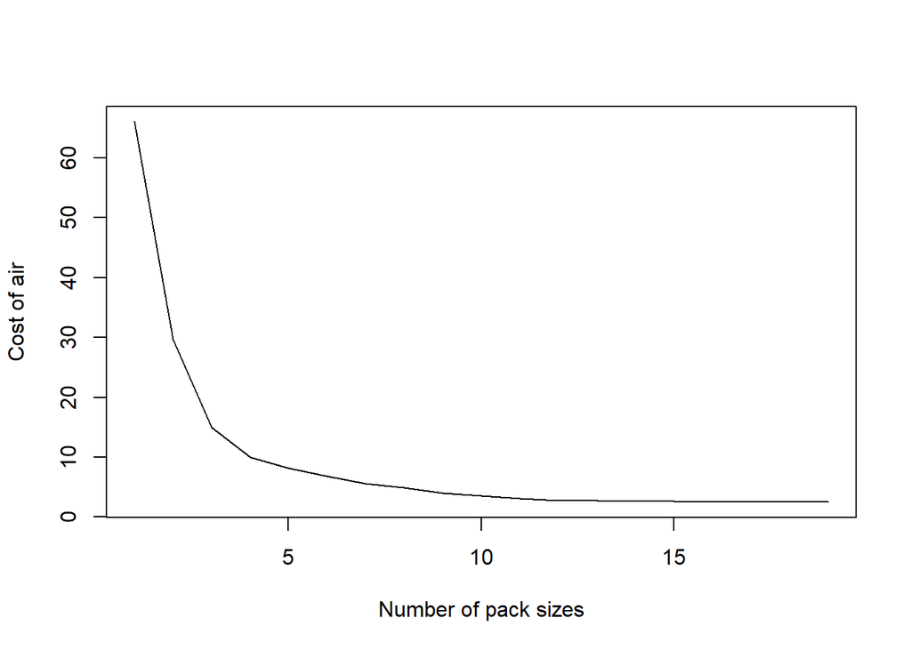

```r
plot(results[,c(1,3)], type = "l", ylab = "Cost of air", xlab = "Number of pack sizes")
```

```r
# pack sizes step by step:
step_packs
```

```
## [[1]]
##  [1]  2  3  4  5  6  7  8  9 10 11 12 13 14 15 16 17 18 19 21
##
## [[2]]
##  [1]  3  4  5  6  7  8  9 10 11 12 13 14 15 16 17 18 19 21
##
## [[3]]
##  [1]  3  4  5  6  7  8  9 10 11 12 13 14 15 16 18 19 21
##
## [[4]]
##  [1]  3  4  5  6  7  8  9 10 11 12 13 14 15 16 18 21
##
## [[5]]
##  [1]  3  4  5  6  7  8  9 10 11 12 13 14 16 18 21
##
## [[6]]
##  [1]  3  4  5  6  7  8  9 10 11 12 13 14 16 21
##
## [[7]]
##  [1]  4  5  6  7  8  9 10 11 12 13 14 16 21
##
## [[8]]
##  [1]  4  5  6  7  8  9 10 11 12 14 16 21
##
## [[9]]
##  [1]  5  6  7  8  9 10 11 12 14 16 21
##
## [[10]]
##  [1]  5  6  7  8  9 10 12 14 16 21
##
## [[11]]
## [1]  5  6  7  8  9 10 12 14 21
##
## [[12]]
## [1]  5  6  7  8 10 12 14 21
##
## [[13]]
## [1]  5  7  8 10 12 14 21
##
## [[14]]
## [1]  5  7  8 10 14 21
##
## [[15]]
## [1]  5  8 10 14 21
##
## [[16]]
## [1]  8 10 14 21
##
## [[17]]
## [1]  8 14 21
##
## [[18]]
## [1]  8 21
##
## [[19]]
## [1] 21
```

```r
# average cost of air by number of pack sizes, using historical and new data
datatable(results)
```

|  | Number of pack sizes | Training data cost of air | Validation data cost of air |
| --- | --- | --- | --- |
| 1 | 19 | 2.51883530442232 | 2.52083761645623 |
| 2 | 18 | 2.52383530442232 | 2.52083761645623 |
| 3 | 17 | 2.53383530442232 | 2.52083761645623 |
| 4 | 16 | 2.55383530442232 | 2.52083761645623 |
| 5 | 15 | 2.60383530442232 | 2.62083761645623 |
| 6 | 14 | 2.67883530442232 | 2.62083761645623 |
| 7 | 13 | 2.75883530442232 | 2.72083761645623 |
| 8 | 12 | 2.89383530442232 | 2.82083761645623 |
| 9 | 11 | 3.16383530442232 | 3.07083761645623 |
| 10 | 10 | 3.45383530442232 | 3.52083761645623 |

[output cut: 9 more lines]

## Alternative: start from a pre-selected list of package sizes

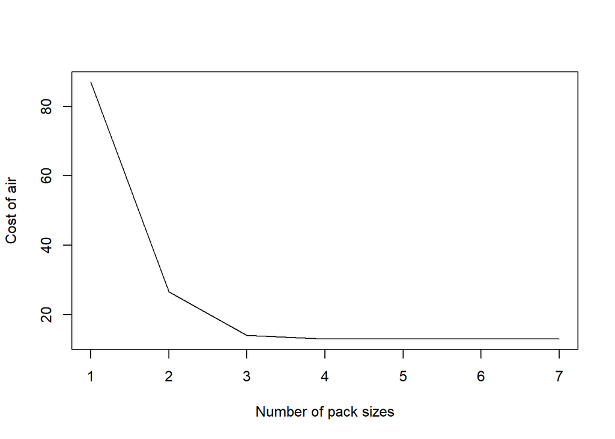

```r
init_packs = c(2, 4, 8, 12, 25, 30, 50)

step_packs = list(init_packs)
x = list(find_next_cluster(train_data, step_packs[[1]]))
step_packs[[2]] = step_packs[[1]][-which.min(x[[1]])]
for (i in 2:(length(init_packs) - 1)) {
  x[[i]] = find_next_cluster(train_data, step_packs[[i]])
  step_packs[[i + 1]] = step_packs[[i]][-which.min(x[[i]])]
}

final_costs =
  sapply(
    step_packs,
    alloc_var_pack,
    cost_per_size,
    hist_data
  ) / length(hist_data)

newdata_costs =
  sapply(
    step_packs,
    alloc_var_pack,
    cost_per_size,
    new_data
  ) / length(new_data)

results = data.frame(
  "Number of pack sizes" = sapply(step_packs, length),
  "Training data cost of air" = final_costs,
  "Validation data cost of air" = newdata_costs,
  check.names = FALSE
)

plot(results[,c(1,2)], type = "l", ylab = "Cost of air", xlab = "Number of pack sizes")
```

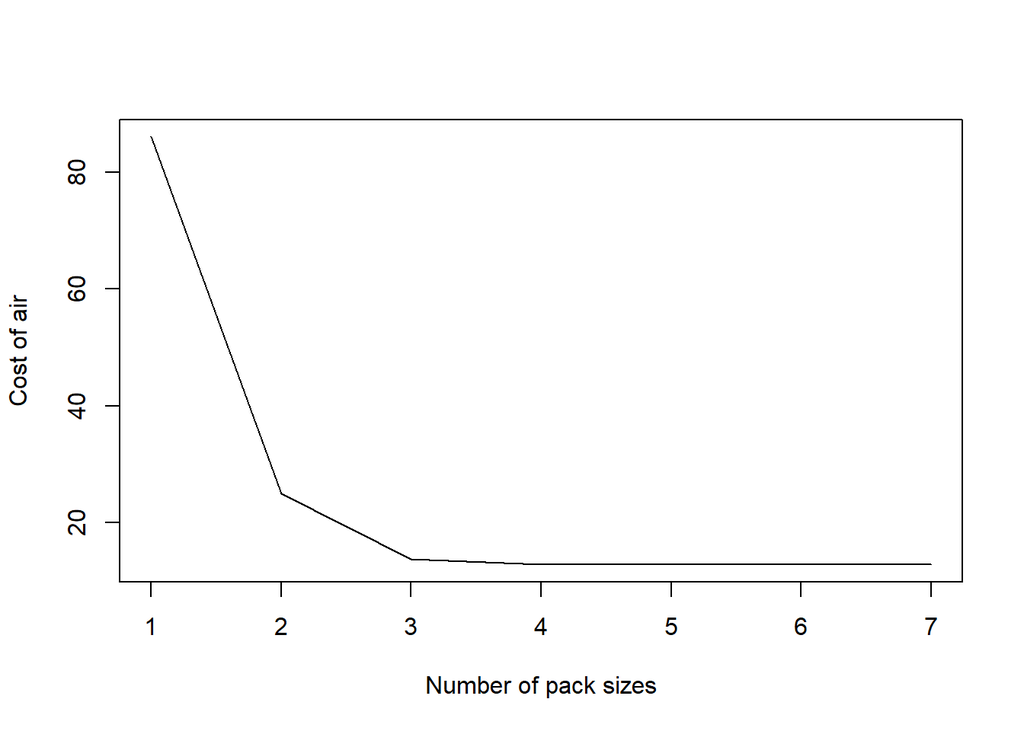

```r
plot(results[,c(1,3)], type = "l", ylab = "Cost of air", xlab = "Number of pack sizes")
```

```r
# pack sizes step by step:
step_packs
```

```
## [[1]]
## [1]  2  4  8 12 25 30 50
##
## [[2]]
## [1]  2  4  8 12 25 50
##
## [[3]]
## [1]  2  4  8 12 25
##
## [[4]]
## [1]  4  8 12 25
##
## [[5]]
## [1]  8 12 25
##
## [[6]]
## [1] 12 25
##
## [[7]]
## [1] 25
```

```r
# average cost of air by number of pack sizes, using historical and new data
datatable(results)
```

|  | Number of pack sizes | Training data cost of air | Validation data cost of air |
| --- | --- | --- | --- |
| 1 | 7 | 13.0088353044223 | 12.7708376164562 |
| 2 | 6 | 13.0088353044223 | 12.7708376164562 |
| 3 | 5 | 13.0088353044223 | 12.7708376164562 |
| 4 | 4 | 13.0188353044223 | 12.7708376164562 |
| 5 | 3 | 14.0988353044223 | 13.7708376164562 |
| 6 | 2 | 26.5588353044223 | 24.9708376164562 |
| 7 | 1 | 87.0088353044223 | 86.0708376164562 |